# Ricardo Lastra

## Welcome

### Welcome!

Este diminuto sitio de la red es para compartir más allá de lo que un repo de código podría comunicar, dándome cuenta la importancia de formalizar todo el trabajo realizado día a día, publicando esas investigaciones, ideas, y formas simples de ir resolviendo la vida. Esta es mi página personal donde comparto la idea del OpenSource y su contribución a mejorar la calidad de vida.

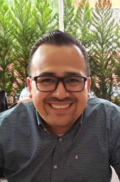

### About

Soy Científico de Datos por educación y experiencia, confió en la habilidad de los datos, la importancia de su origen y como es que fueron creados. Actualmente colaboro en la División de Negocios Especiales como Científico de Datos, encargado de generar sinergia en grandes negocios con todas las áreas de Seguros Atlas.

Mi experiencia va en función de los proyectos que el mercado de seguros demanda y del motor que mueve a la compañía, la gente. Actualmente me encargo de llevar a cabo varios proyectos, que pasan desde algoritmos de renovaciones de pólizas individuales hasta estadística para socios internacionales, cuentas de gobierno, y grandes riesgos de diversos ramos.

También he generado la puesta a punto de proyectos innovadores como el Seguro de Terremoto paramétrico que se comercializa en línea por SUPER SEGUROS.

Aprender asuntos operativos, involucramiento en varias áreas de la organización de Seguros me ha llevado a generar una amplia experiencia y conocimiento del negocio, donde he logrado desarrollar una visión de las fortalezas y oportunidades de la organización.

Mi trabajo ha generado un gran impacto en la organización, tano en el recurso humano como en la mejora de sistemas, procesos y proyectos de gran alcance.

Educación.

- Maestría en Ciencia de Datos por el Instituto Autónomo de México (ITAM).
- Licenciatura en Administración por la Universidad del Valle de México (UVM).
- Técnico en Administración por el Instituto Politécnico Nacional (IPN).

### Teaching

He participado en la generación de algunos cursos, mi visión es que cualquier persona puede programar y aprender a usar la información, combatiendo la ignorancia por el bien común, y con ideologías de bienestar global. Recientemente desarrolle un par de Workshops, donde el objetivo es ensuciarse las manos con un poco de Código Abierto y de incrementar el nivel profesional de los participantes.

#### Workshops

`R for insurance`

Workshop para no programadores, donde echamos un vistazo a una introducción de R, revisando programación básica y sintaxis, hasta aprender a realizar reportes RMD y realizar algunos algoritmos de texto con librerías como `tm` y `qdap`. Analizamos 2 versiones de la Bilia Reina Valera ed. 1602 y 1909, después de una breve limpieza de texto pasamos en una Matriz las palabras con mayor Frecuencia

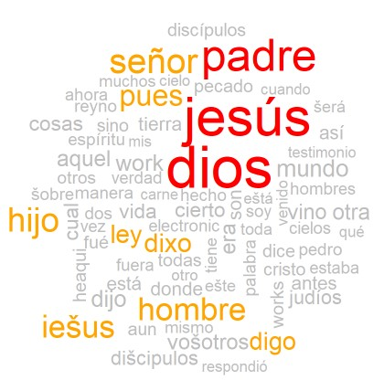

Usando las palabras con Frecuencia mayor a n=50, exploramos la librería `stringdist` la cual está llena de algoritmos de texto, usando el algoritmo `Jaro-Winkler` ó distancia winkler pudimos generar el siguiente Dendograma

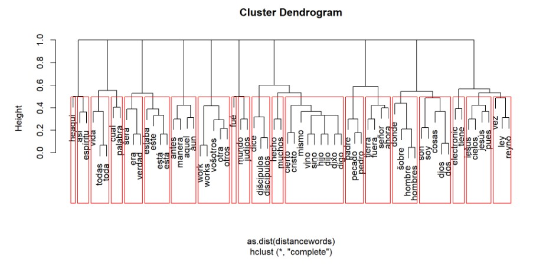

El material se puede ver aquí, el cual fue inspirado para que NO programadores tuvieran un acercamiento a estos temas, dando múltiples resultados y beneficios en los participantes.

### Research & Development

Actualmente desarrollo una 3ra versión de un Workshop de ‘R’ dirigido a Actuarios y Desarrolladores, así como un curso intermedio-avanzado como introducción a la Ciencia de Datos para colegas con más experiencia y más años de arrastrar la tecla.

También llevo algún tiempo puliendo modelos para la predicción de renovaciones, usando algunas técnicas como ML, Clusterización y algunos algoritmos de transformación matricial.

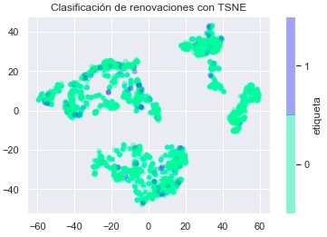

A work by Ricardo Lastra. [Mi repo en Git](https://github.com/ricardolastra/)

*Efesios 5:15-17*